# Lab12

Clayton Glenn

April 13, 2018

# 1 Task1

```r
getwd()
```

```
## [1] "C:/Users/cglen/Desktop/Stat Methods/Labs/LAB12"
```

# 2 Task2

## 2.1 Set Data

```r
set.seed(55);x1=rnorm(30,mean=25,sd=5)
```

## 2.2 TTests

```r
t.test(x1,mu=22)
```

```
##
##  One Sample t-test
##
## data:  x1
## t = 3.3863, df = 29, p-value = 0.002052
## alternative hypothesis: true mean is not equal to 22
## 95 percent confidence interval:
##  23.30198 27.27320
## sample estimates:
## mean of x
##  25.28759
```

```r
t.test(x1,mu=23)
```

```
##
##  One Sample t-test
##
## data:  x1
## t = 2.3563, df = 29, p-value = 0.02543
## alternative hypothesis: true mean is not equal to 23
## 95 percent confidence interval:
##  23.30198 27.27320
## sample estimates:
## mean of x
##  25.28759
```

```r
t.test(x1,mu=24)
```

```
##
##  One Sample t-test
##
## data:  x1
## t = 1.3263, df = 29, p-value = 0.1951
## alternative hypothesis: true mean is not equal to 24
## 95 percent confidence interval:
##  23.30198 27.27320
## sample estimates:
## mean of x
##  25.28759
```

```r
t.test(x1,mu=25)
```

```
##
##  One Sample t-test
##
## data:  x1
## t = 0.29623, df = 29, p-value = 0.7692
## alternative hypothesis: true mean is not equal to 25
## 95 percent confidence interval:
##  23.30198 27.27320
## sample estimates:
## mean of x
##  25.28759
```

```r
t.test(x1,mu=26)
```

```
##
##  One Sample t-test
##
## data:  x1
## t = -0.7338, df = 29, p-value = 0.469
## alternative hypothesis: true mean is not equal to 26
## 95 percent confidence interval:
##  23.30198 27.27320
## sample estimates:
## mean of x
##  25.28759
```

## 2.3 Boxplot with Confidence intervals and Mean

```r
boxplot(x1, main="Sample x1")
ci=t.test(x1,mu=22)$conf.int
ci
```

```
## [1] 23.30198 27.27320
## attr(,"conf.level")
## [1] 0.95
```

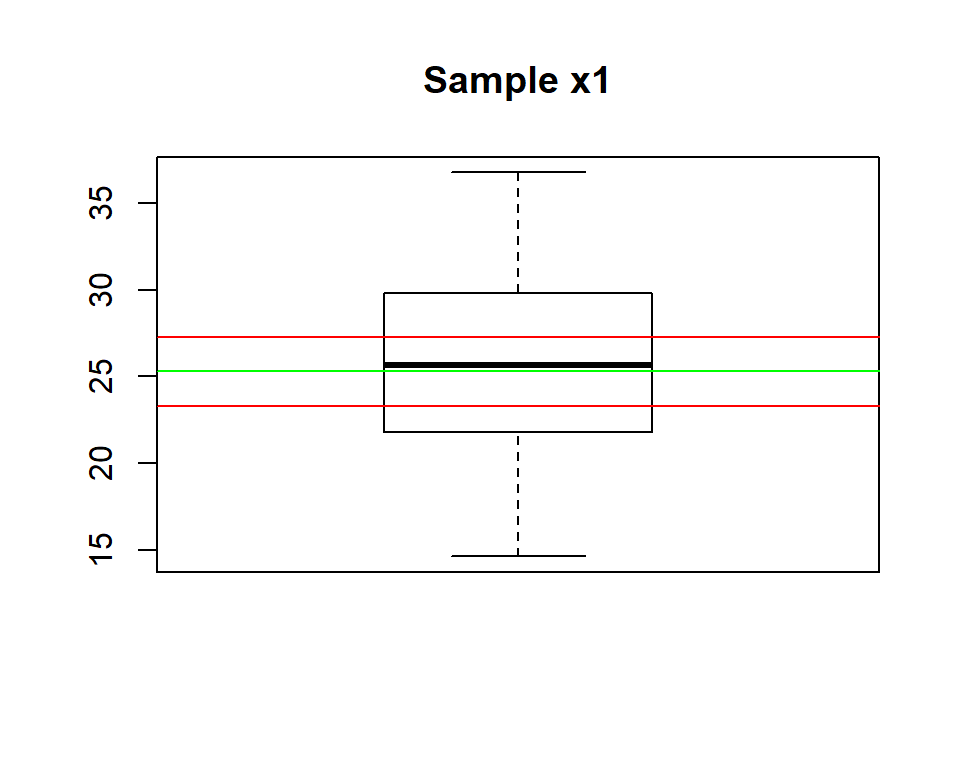

```r
abline(h=c(ci,mean(x1)),col=c("Red","Red","Green"))
```

## 2.4 TCalc

```r
tcalc=(mean(x1)-24)/(sd(x1)/sqrt(30))
tcalc
```

```
## [1] 1.326252
```

## 2.5 P-Value Function

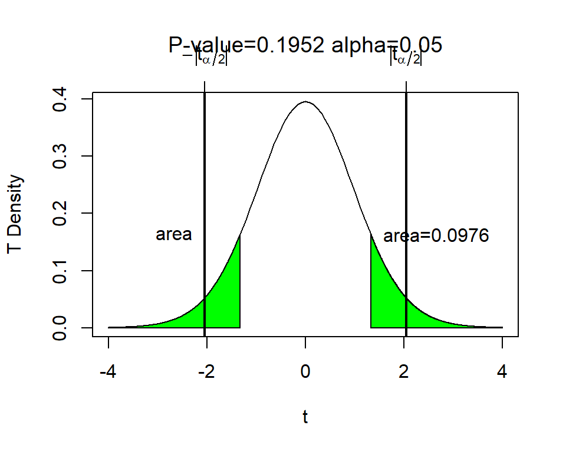

```
## $q
## [1] 2.04523
##
## $pvalue
## [1] 0.1952
```

```r
mypvalue=function(t0,xmax=4,n=20, alpha=0.05){

  va=round(pt(-t0,df=n-1),4)
  pv=2*va

  curve(dt(x,df=n-1),xlim=c(-xmax,xmax),ylab="T Density",xlab=expression(t),
        main=substitute(paste("P-value=", pv, " alpha=", alpha)))

  xcurve=seq(t0,xmax,length=1000)
  ycurve=dt(xcurve,df=n-1)

  xlcurve=seq(-t0,-xmax,length=1000)
  ylcurve=dt(xcurve,df=n-1)

  polygon(c(t0,xcurve,xmax),c(0,ycurve,0),col="green")
  polygon(c(-t0,xlcurve,-xmax),c(0,ylcurve,0),col="green")

  q=qt(1-alpha/2,n-1)
  abline( v=c(q,-q),lwd=2)
  axis(3,c(q,-q),c(expression(abs(t[alpha/2])),expression(-abs(t[alpha/2]))))

  text(0.5*(t0+xmax),max(ycurve),substitute(paste(area, "=",va)))
  text(-0.5*(t0+xmax),max(ycurve),expression(area))

  return(list(q=q,pvalue=pv))
}
mypvalue(tcalc,n=30,alpha=0.05)
```

## 2.6 Bootstrap Function

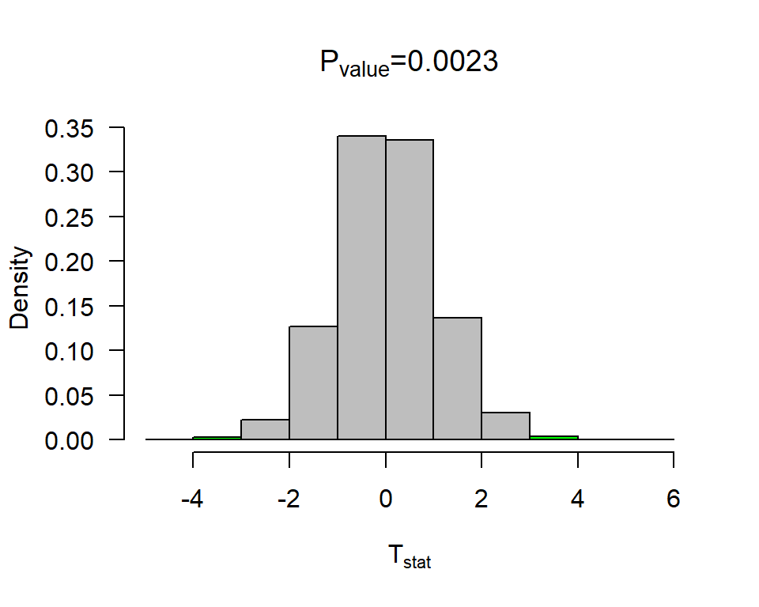

```
## $pvalue
## [1] 0.002333333
##
## $tcalc
## [1] 3.386302
##
## $n
## [1] 30
##
## $x
##  [1] 25.60070 15.93812 25.75791 19.40389 25.00954 30.94259 22.47328
##  [8] 24.50383 26.52677 25.99205 24.75545 20.78383 14.62365 23.19618
## [15] 21.81155 23.16861 36.77682 30.46689 26.42921 29.96829 17.40364
## [22] 32.48559 29.09808 30.33025 28.66878 29.80172 21.53910 32.02999
## [29] 16.83231 26.30915
##
## $test
## [1] "two"
##
## $ci
##     2.5%    97.5%
## 23.36578 27.13615
```

```r
bootpval<-function(x,conf.level=0.95,iter=3000,mu0=0, test="two"){
  n=length(x)
  y=x-mean(x)+mu0
  rs.mat<-c()
  xrs.mat<-c()
  for(i in 1:iter){
    rs.mat<-cbind(rs.mat,sample(y,n,replace=TRUE))
    xrs.mat<-cbind(xrs.mat,sample(x,n,replace=TRUE))

  }

  tstat<-function(z){
    sqrt(n)*(mean(z)-mu0)/sd(z)
  }

  tcalc=tstat(x)
  ytstat=apply(rs.mat,2,tstat)
  xstat=apply(xrs.mat,2,mean)
  alpha=1-conf.level
  ci=quantile(xstat,c(alpha/2,1-alpha/2))
  pvalue=ifelse(test=="two",length(ytstat[ytstat>abs(tcalc) | ytstat < -abs(tcalc)])/iter,
                ifelse(test=="upper",length(ytstat[ytstat>tcalc])/iter,
                       length(ytstat[ytstat<xstat])/iter))

  h=hist(ytstat,plot=FALSE)
  mid=h$mid
  if(test=="two"){
    ncoll=length(mid[mid<= -abs(tcalc)])
    ncolr=length(mid[mid>=  abs(tcalc)])
    col=c(rep("Green",ncoll),rep("Gray",length(mid)-ncoll-ncolr),rep("Green",ncolr))
  }
  if(test=="upper"){
    ncolr=length(mid[mid>=  abs(tcalc)])
    col=c(rep("Gray",length(mid)-ncolr),rep("Green",ncolr))
  }

  if(test=="lower"){
    ncoll=length(mid[mid<=  -abs(tcalc)])
    col=c(rep("Green",ncoll),rep("Gray",length(mid)-ncoll))
  }
  hist(ytstat,col=col,freq=FALSE,las=1,main="",xlab=expression(T[stat]))
  segments(ci[1],0,ci[2],0,lwd=2)
  pround=round(pvalue,4)
  title(substitute(paste(P[value],"=",pround)))
  return(list(pvalue=pvalue,tcalc=tcalc,n=n,x=x,test=test,ci=ci))
}
bootpval(x=x1,mu0=22,test="two")
```

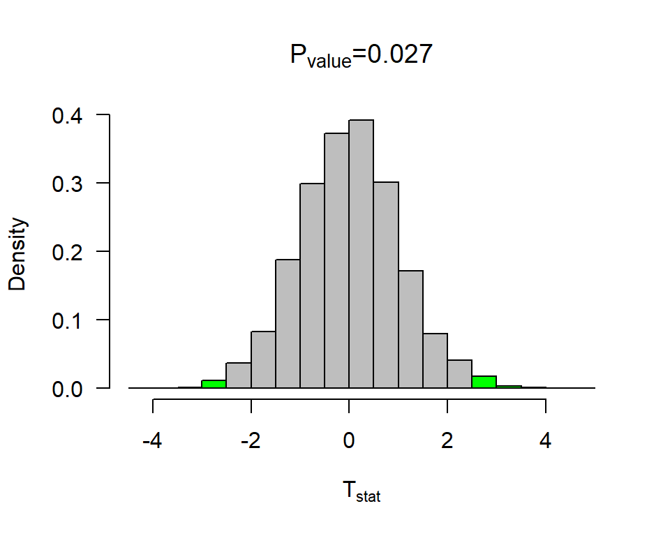

```
## $pvalue
## [1] 0.027
##
## $tcalc
## [1] 2.356277
##
## $n
## [1] 30
##
## $x
##  [1] 25.60070 15.93812 25.75791 19.40389 25.00954 30.94259 22.47328
##  [8] 24.50383 26.52677 25.99205 24.75545 20.78383 14.62365 23.19618
## [15] 21.81155 23.16861 36.77682 30.46689 26.42921 29.96829 17.40364
## [22] 32.48559 29.09808 30.33025 28.66878 29.80172 21.53910 32.02999
## [29] 16.83231 26.30915
##
## $test
## [1] "two"
##
## $ci
##     2.5%    97.5%
## 23.35295 27.15016
```

```r
bootpval(x=x1,mu0=23,test="two")
```

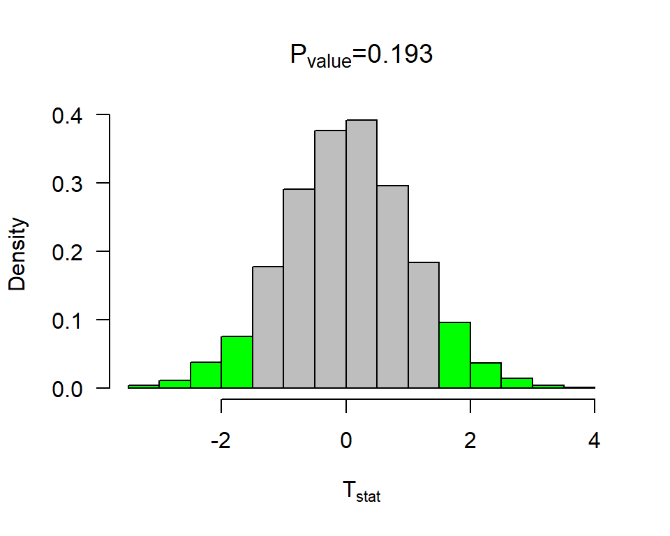

```
## $pvalue
## [1] 0.193
##
## $tcalc
## [1] 1.326252
##
## $n
## [1] 30
##
## $x
##  [1] 25.60070 15.93812 25.75791 19.40389 25.00954 30.94259 22.47328
##  [8] 24.50383 26.52677 25.99205 24.75545 20.78383 14.62365 23.19618
## [15] 21.81155 23.16861 36.77682 30.46689 26.42921 29.96829 17.40364
## [22] 32.48559 29.09808 30.33025 28.66878 29.80172 21.53910 32.02999
## [29] 16.83231 26.30915
##
## $test
## [1] "two"
##
## $ci
##     2.5%    97.5%
## 23.42505 27.10562
```

```r
bootpval(x=x1,mu0=24,test="two")
```

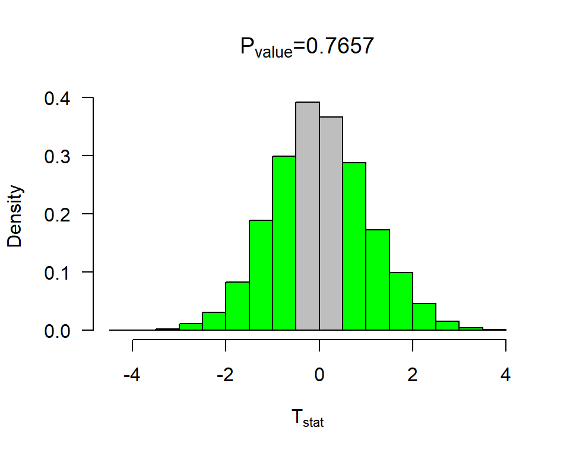

```
## $pvalue
## [1] 0.7656667
##
## $tcalc
## [1] 0.2962266
##
## $n
## [1] 30
##
## $x
##  [1] 25.60070 15.93812 25.75791 19.40389 25.00954 30.94259 22.47328
##  [8] 24.50383 26.52677 25.99205 24.75545 20.78383 14.62365 23.19618
## [15] 21.81155 23.16861 36.77682 30.46689 26.42921 29.96829 17.40364
## [22] 32.48559 29.09808 30.33025 28.66878 29.80172 21.53910 32.02999
## [29] 16.83231 26.30915
##
## $test
## [1] "two"
##
## $ci
##     2.5%    97.5%
## 23.41679 27.24529
```

```r
bootpval(x=x1,mu0=25,test="two")
```

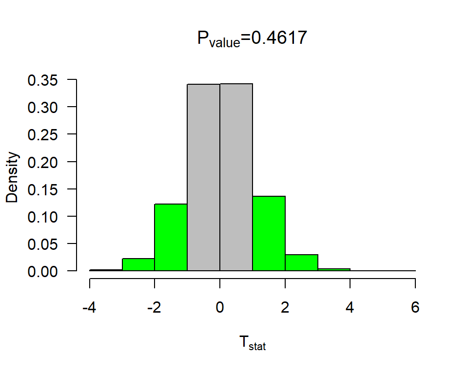

```
## $pvalue
## [1] 0.4616667
##
## $tcalc
## [1] -0.7337985
##
## $n
## [1] 30
##
## $x
##  [1] 25.60070 15.93812 25.75791 19.40389 25.00954 30.94259 22.47328
##  [8] 24.50383 26.52677 25.99205 24.75545 20.78383 14.62365 23.19618
## [15] 21.81155 23.16861 36.77682 30.46689 26.42921 29.96829 17.40364
## [22] 32.48559 29.09808 30.33025 28.66878 29.80172 21.53910 32.02999
## [29] 16.83231 26.30915
##
## $test
## [1] "two"
##
## $ci
##     2.5%    97.5%
## 23.44446 27.21564
```

```r
bootpval(x=x1,mu0=26,test="two")
```

# 3 Task3

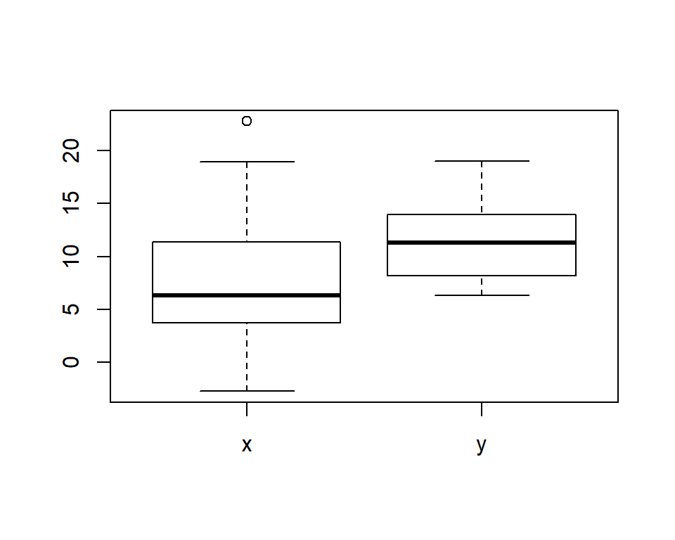

```r
set.seed(30);x=rnorm(15,mean=10,sd=7)
set.seed(40);y=rnorm(20,mean=12,sd=4)

boxplot(list(x=x,y=y))
```

```r
var.test(x,y)
```

```
##
##  F test to compare two variances
##
## data:  x and y
## F = 3.3363, num df = 14, denom df = 19, p-value = 0.01596
## alternative hypothesis: true ratio of variances is not equal to 1
## 95 percent confidence interval:
##  1.260446 9.544255
## sample estimates:
## ratio of variances
##            3.33631
```

```r
t.test(x,y, mu=0,var.equal=FALSE)
```

```
##
##  Welch Two Sample t-test
##
## data:  x and y
## t = -1.7945, df = 20.248, p-value = 0.08768
## alternative hypothesis: true difference in means is not equal to 0
## 95 percent confidence interval:
##  -7.9632156  0.5950525
## sample estimates:
## mean of x mean of y
##  7.990343 11.674425
```

```r
t.test(x,y, mu=2,var.equal=FALSE)
```

```
##
##  Welch Two Sample t-test
##
## data:  x and y
## t = -2.7687, df = 20.248, p-value = 0.01176
## alternative hypothesis: true difference in means is not equal to 2
## 95 percent confidence interval:
##  -7.9632156  0.5950525
## sample estimates:
## mean of x mean of y
##  7.990343 11.674425
```

According to var test, we should show the variances unequal with the p value. In Summary, as mean1 - mean2 = 0, we do not have sufficient evidence to reject the null, but as mean1-mean2=2, we can reject the null hypothesis. This seems hand in hand since estimated mean1 < estimated mean2 and they vary significantly.

# 4 Task4

```r
set.seed(30);x=rnorm(15,mean=10,sd=4)
set.seed(40);y=rnorm(20,mean=12,sd=4)

var.test(x,y)
```

```
##
##  F test to compare two variances
##
## data:  x and y
## F = 1.0894, num df = 14, denom df = 19, p-value = 0.8454
## alternative hypothesis: true ratio of variances is not equal to 1
## 95 percent confidence interval:
##  0.4115743 3.1164915
## sample estimates:
## ratio of variances
##           1.089407
```

```r
t.test(x,y, mu=0,var.equal=FALSE)
```

```
##
##  Welch Two Sample t-test
##
## data:  x and y
## t = -2.0494, df = 29.581, p-value = 0.04939
## alternative hypothesis: true difference in means is not equal to 0
## 95 percent confidence interval:
##  -5.637517565 -0.008082348
## sample estimates:
## mean of x mean of y
##  8.851625 11.674425
```

```r
t.test(x,y, mu=2,var.equal=FALSE)
```

```
##
##  Welch Two Sample t-test
##
## data:  x and y
## t = -3.5014, df = 29.581, p-value = 0.001491
## alternative hypothesis: true difference in means is not equal to 2
## 95 percent confidence interval:
##  -5.637517565 -0.008082348
## sample estimates:
## mean of x mean of y
##  8.851625 11.674425
```

According to var test, we should show the variances equal with the p value. In Summary, as mean1 - mean2 = 0 and as mean1-mean2=2, we can reject the null hypothesis. This seems hand in hand since estimated means are closer quartiles.

# 5 Task5

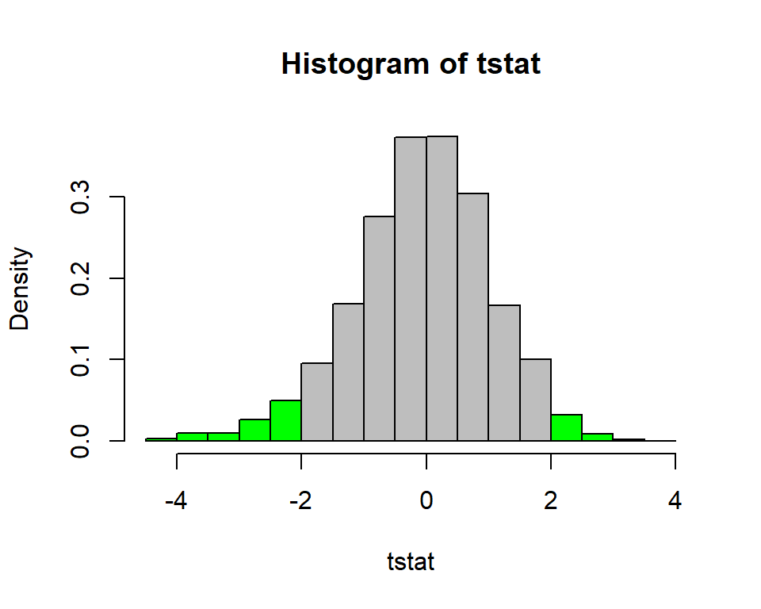

```
## $pvalue
## [1] 0.104
```

```r
boot2pval<-function(x1,x2,conf.level=0.95,iter=3000,mudiff=0, test="two"){
  n1=length(x1)
  n2=length(x2)
  y1=x1-mean(x1)+mean(c(x1,x2))  # transform the data so that it is centered at the NULL
  y2=x2-mean(x2)+mean(c(x1,x2))
  y1rs.mat<-c()    #rs.mat will be come a resample matrix -- now it is an empty vector
  x1rs.mat<-c()
  y2rs.mat<-c()
  x2rs.mat<-c()
  for(i in 1:iter){ # for loop - the loop will go around iter times
    y1rs.mat<-cbind(y1rs.mat,sample(y1,n1,replace=TRUE)) #sampling from y cbind -- column bind -- binds the vectors together by columns
    y2rs.mat<-cbind(y2rs.mat,sample(y2,n2,replace=TRUE))

  }
  x1rs.mat<-y1rs.mat+mean(x1)-mean(c(x1,x2))
  x2rs.mat<-y2rs.mat+mean(x2)-mean(c(x1,x2))

  xbar1=mean(x1)
  xbar2=mean(x2)
  sx1sq=var(x1)
  sx2sq=var(x2)

  tcalc=(xbar1-xbar2-mudiff)/sqrt(sx1sq/n1+sx2sq/n2)

  sy1sq=apply(y1rs.mat,2,var)
  sy2sq=apply(y2rs.mat,2,var)
  y1bar=apply(y1rs.mat,2,mean)
  y2bar=apply(y2rs.mat,2,mean)

  tstat=(y1bar-y2bar-mudiff)/sqrt(sy1sq/n1+sy2sq/n2)


  alpha=1-conf.level
  pvalue=ifelse(test=="two",length(tstat[tstat>abs(tcalc) | tstat < -abs(tcalc)])/iter,
                ifelse(test=="upper",length(tstat[tstat>tcalc])/iter,
                       length(ytstat[tstat<tcalc])/iter))

  h=hist(tstat,plot=FALSE)
  mid=h$mid
  if(test=="two"){
    ncoll=length(mid[mid<= -abs(tcalc)])
    ncolr=length(mid[mid>=  abs(tcalc)])
    col=c(rep("Green",ncoll),rep("Gray",length(mid)-ncoll-ncolr),rep("Green",ncolr))
  }
  hist(tstat,col=col,freq=FALSE)

  return(list(pvalue=pvalue))
}
set.seed(30);x=rnorm(15,mean=10,sd=7)
set.seed(40);y=rnorm(20,mean=12,sd=4)
boot2pval(x1=x,x2=y)
```

# 6 Task6

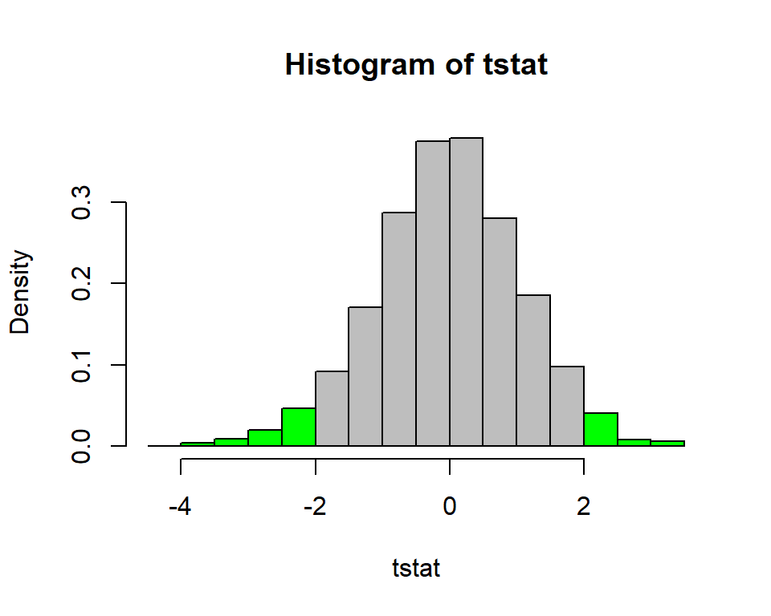

```
## $pvalue
## [1] 0.06033333
```

```r
set.seed(30);x=rnorm(15,mean=10,sd=4)
set.seed(40);y=rnorm(20,mean=12,sd=4)
boot2pval(x1=x,x2=y)
```

# 7 Task7

## 7.2 B

Line B shows that the t test is only associated with 1 set of data

## 7.3 C

Line C Shows the T calc, the degrees of freedom and the p value of the data with the null hypothesis. P-Value getting to small, kick H-not out the door.

## 7.4 D

Line D shows the functions interpretation of the P-Value with the mean.

## 7.5 E

The t test is over a 95% confidence interval that shows we are 95% confident that the mean lies within this region.

## 7.7 G

Line G shows according to the t test, the mean of the data should be estimated around 25.28759.